# Deskriptivní statistiky časových řad

### Prices

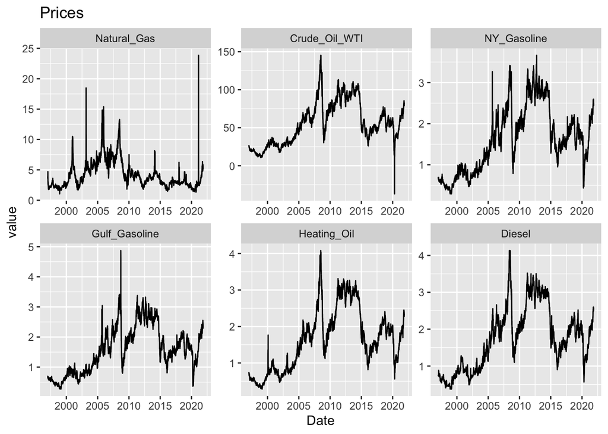

```r
long_df <- reshape2::melt(df, id.vars = c("Date","Day"))

ggplot(long_df, aes(x = Date, y = value)) +
  geom_line() +
  facet_wrap(~variable, scales = "free") +
  ggtitle("Prices") +
  geom_vline(xintercept = as.POSIXct("2008-9-15"), color = "Red")
```

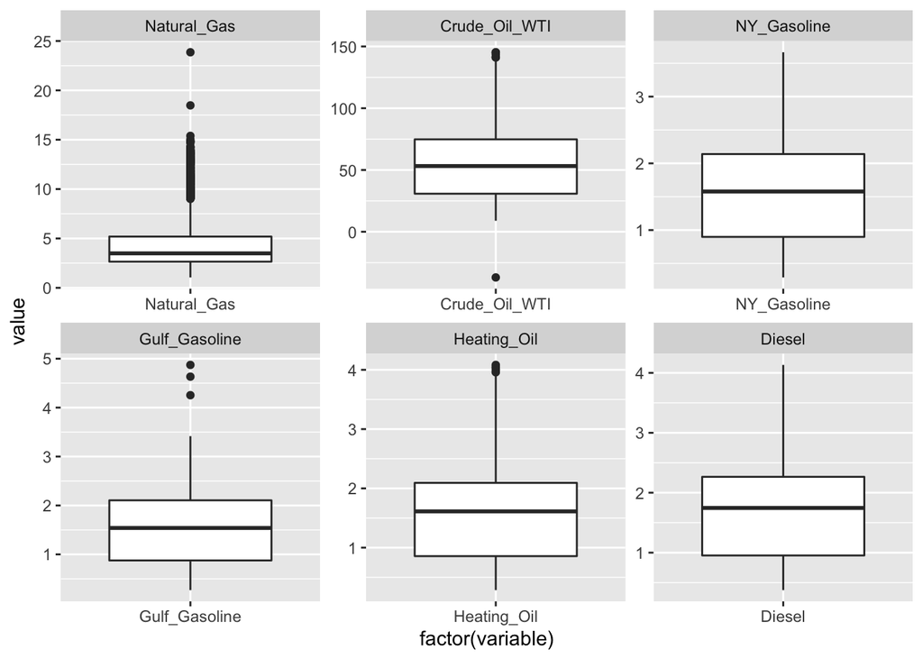

```r
ggplot(long_df, aes(factor(variable), value)) +
geom_boxplot() +
facet_wrap(~variable, scale="free")
```

We see that this **crude oil WTI metric** had negative prices at one point. This would not let us do log-returns, so we substitute with low value for now. Should be treated more rigorously later on.

```r
df[df$Date=="2020-04-20","Crude_Oil_WTI"]<-0.01
```

### Log returns

```r
log_ret_df <- tibble(df[2:nrow(df), "Date"])

for (i in 3:(ncol(df))) {
  var_name <- paste(colnames(df)[i], "log_ret", sep = "_")
  vals <- log(df[, i]) %>% pull()
  lag_vals <- base::diff(vals, lag = 1)
  log_ret_df[var_name] <- lag_vals
}
long_log_ret <- melt(log_ret_df, id.vars = "Date")
```

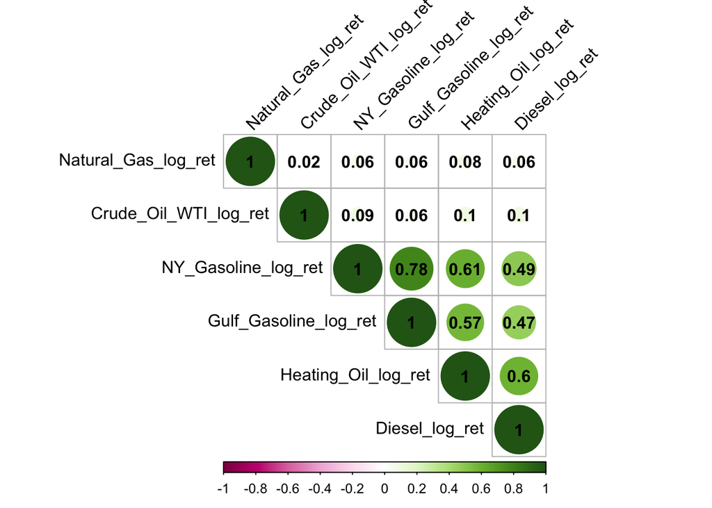

```r
cor_long_df <- cor(log_ret_df[,-1])
corrplot(cor_long_df, type="upper", order="hclust", tl.col="black", tl.srt=45,
         col = COL2('PiYG'), cl.pos = 'b', addCoef.col = 'black')
```

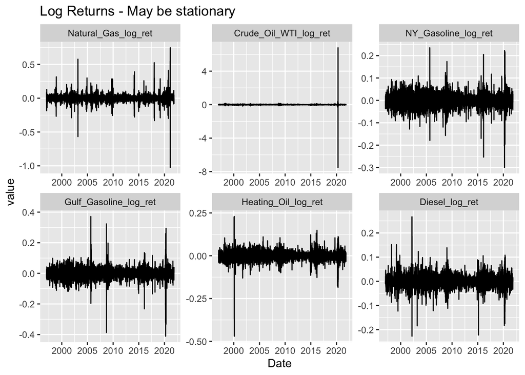

```r
ggplot(long_log_ret, aes(x = Date, y = value)) +
  geom_line() +
  facet_wrap(~variable, scales = "free") +
  ggtitle("Log Returns - May be stationary")
```

## Summary and Statistical Tests

```r
ar_1_list <- list()
q_10_list<- list()
q2_10_list<- list()
ma_1_list <- list()
arch_5_list<-list()
shapiro_norm_list<-list()
adf_list<-list()
jarque_bera_list<-list()

for(i in 2:length(log_ret_df)){
  val<-log_ret_df[,i] %>% pull()
  res<-lm(val~I(lagpad(val, 1)))$residuals
  shapiro_norm_list[[i-1]]<-shapiro.test(sample(val,size=5000,replace = F))
  adf_list[[i-1]] <- adf.test(val)
  ma_1_list[[i-1]] <- arima(val, order = c(0, 0, 1))
  ar_1_list[[i-1]] <- arima( res, order = c(1, 0, 0))
  q_10_list[[i-1]]<-Box.test(res, lag = 10, type =  "Ljung-Box")
  q2_10_list[[i-1]]<-Box.test(res^2, lag = 10, type =  "Ljung-Box")
  arch_5_list[[i-1]]<- quiet(garch(res,c(0,5)))
  jarque_bera_list[[i-1]]<-jarque.bera.test(val)
}
```

[output not shown]

```r
sp_list<-lsf.str("package:frequencyConnectedness")
sp_list<-sp_list[str_detect(sp_list,"spill")]
print(sp_list)
```

```
## [1] "spilloverBK09"        "spilloverBK12"        "spilloverDY09"
## [4] "spilloverDY12"        "spilloverRollingBK09" "spilloverRollingBK12"
## [7] "spilloverRollingDY09" "spilloverRollingDY12"
```

```r
help(sp_list[1])
```

| spilloverBK09 | R Documentation |
| --- | --- |

## Computing the decomposed spillover from a fevd as defined by Barunik, Krehlik (2018)

### Description

This function is an internal implementation of the frequency spillover. We apply the identification scheme suggested by fevd to the frequency decomposition of the transfer functions from the estimate est.

### Usage

```r
spilloverBK09(est, n.ahead = 100, no.corr, partition)
```

### Arguments

| `est` | the estimate of a system, typically VAR estimate in our case |
| --- | --- |
| `n.ahead` | how many periods ahead should the FEVD be computed, generally this number should be high enough so that it won’t change with additional period |
| `no.corr` | boolean parameter whether the off-diagonal in the covariance matrix should be set to zero |
| `partition` | defines the frequency partitions to which the spillover should be decomposed |

### Value

spillover_table object

### Author(s)

Tomas Krehlik <tomas.krehlik@gmail.com>

```r
log_ret_df<-log_ret_df[-1] #no date
est <- VAR(log_ret_df, p = 2, type = "const")
sp<-spilloverDY09(est, n.ahead = 100, no.corr = F)
```

```r
overall(sp)
```

```
## [[1]]
## [1] 25.150399
```

```r
to(sp)
```

```
## [[1]]
##   Natural_Gas_log_ret Crude_Oil_WTI_log_ret   NY_Gasoline_log_ret
##           0.323568742           2.486000882          19.320921295
## Gulf_Gasoline_log_ret   Heating_Oil_log_ret        Diesel_log_ret
##           0.743888202           2.237308856           0.038711254
```

```r
from(sp)
```

```
## [[1]]
##   Natural_Gas_log_ret Crude_Oil_WTI_log_ret   NY_Gasoline_log_ret
##           0.156215087           0.071940702           1.004311986
## Gulf_Gasoline_log_ret   Heating_Oil_log_ret        Diesel_log_ret
##          10.507354694           6.817662168           6.592914594
```

```r
net(sp)
```

```
## [[1]]
##   Natural_Gas_log_ret Crude_Oil_WTI_log_ret   NY_Gasoline_log_ret
##            0.16735365            2.41406018           18.31660931
## Gulf_Gasoline_log_ret   Heating_Oil_log_ret        Diesel_log_ret
##           -9.76346649           -4.58035331           -6.55420334
```

```r
pairwise(sp)
```

```
## [[1]]
##   Natural_Gas_log_ret-Crude_Oil_WTI_log_ret
##                               -0.0136647511
##     Natural_Gas_log_ret-NY_Gasoline_log_ret
##                                0.0068982195
##   Natural_Gas_log_ret-Gulf_Gasoline_log_ret
##                               -0.0581977339
##     Natural_Gas_log_ret-Heating_Oil_log_ret
##                               -0.0469616071
##          Natural_Gas_log_ret-Diesel_log_ret
##                               -0.0554277821
##   Crude_Oil_WTI_log_ret-NY_Gasoline_log_ret
##                               -0.7262046517
## Crude_Oil_WTI_log_ret-Gulf_Gasoline_log_ret
##                               -0.8649553622
##   Crude_Oil_WTI_log_ret-Heating_Oil_log_ret
##                               -0.4526777015
##        Crude_Oil_WTI_log_ret-Diesel_log_ret
##                               -0.3838872158
##   NY_Gasoline_log_ret-Gulf_Gasoline_log_ret
##                               -9.4057122395
##     NY_Gasoline_log_ret-Heating_Oil_log_ret
##                               -5.8555918051
##          NY_Gasoline_log_ret-Diesel_log_ret
##                               -3.7746116972
##   Gulf_Gasoline_log_ret-Heating_Oil_log_ret
##                               -0.3115174639
##        Gulf_Gasoline_log_ret-Diesel_log_ret
##                               -0.2538813801
##          Heating_Oil_log_ret-Diesel_log_ret
##                               -2.0863952648
```

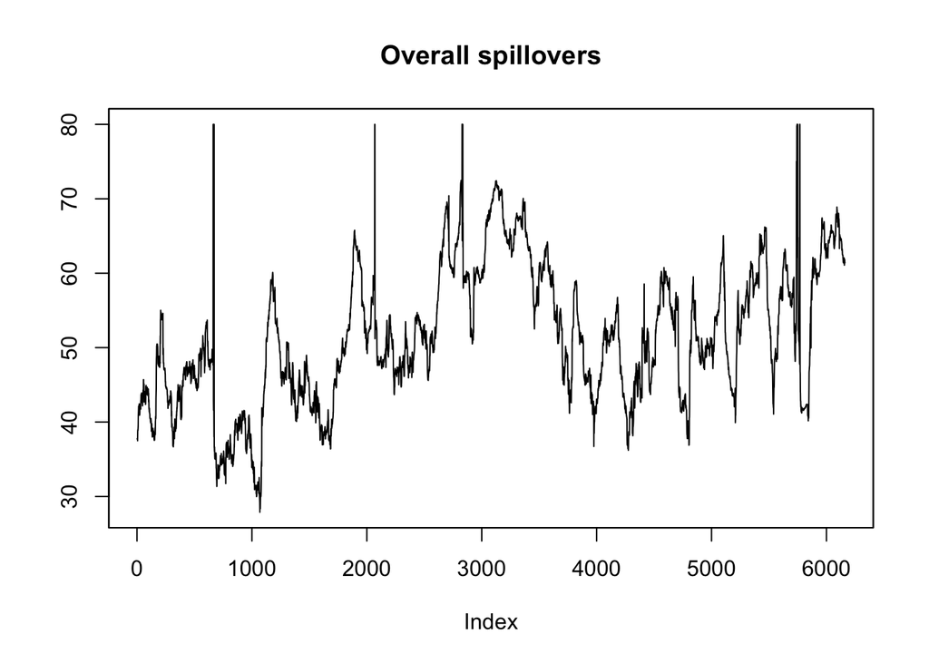

```r
# Get the rolling window estimates
params_est = list(p = 2, type = "const")
sp <- spilloverRollingDY09(log_ret_df[-1], n.ahead = 100, no.corr = F, "VAR", params_est = params_est, window = 100)
plotOverall(sp)
```

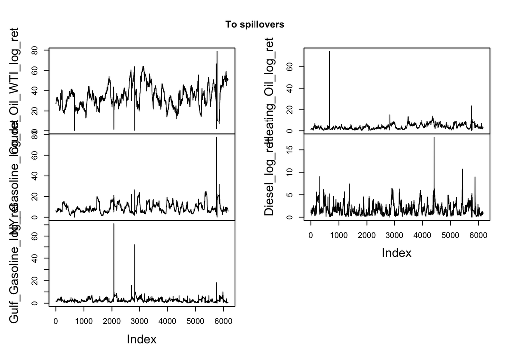

```r
plotTo(sp)
```

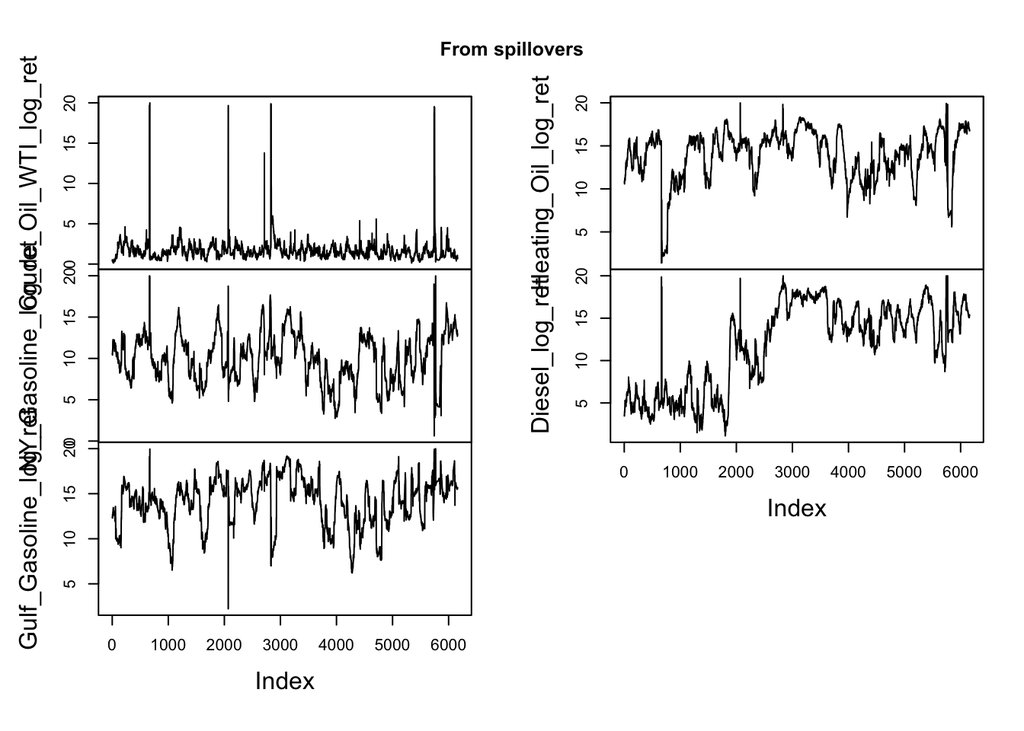

```r
plotFrom(sp)
```